# HW5

ECON 21130

Raymond Han

3/4/17

```r
require(kableExtra)
require(ggplot2)
require(texreg)
require(readstata13) #to install, run install.packages("readstata13")
require(sandwich)
require(lmtest)
require(dplyr)
options(knitr.table.format = "html")
```

# A Simple Model

The unemployed Worker Bellman equation is given by
$$V_u = \max_\lambda b_i - c(\lambda) + \lambda_i \frac{\rho W_i}{(1+r)r}+\frac{1-\lambda_i}{1+r}V_u$$

Question 1 For fixed $\lambda$, We can write
$$V_u = b_i - c(\lambda) + \lambda_i \frac{\rho W_i}{(1+r)r}+\frac{1-\lambda_i}{1+r}V_u \\
\frac{r+\lambda_i}{1+r}V_u = b_i - c(\lambda) + \lambda_i \frac{\rho W_i}{(1+r)r} \\
V_u = \frac{1+r}{r+\lambda_i}\left(b_i - c(\lambda) + \lambda_i \frac{\rho W_i}{(1+r)r}\right)$$

Specifying that $c(\lambda)=\frac{a}{\gamma}\lambda^{1+\gamma}$,
$$V_u = \frac{1+r}{r+\lambda_i}\left(b_i - \frac{a}{\gamma}\lambda_i^{1+\gamma} + \lambda_i \frac{\rho W_i}{(1+r)r}\right).$$

Question 2 The agent will try to maximize the above. Taking the FOC with respect to $\lambda_i$,
$$-\frac{1+r}{(r+\lambda_i)^2}\left(b_i - \frac{a}{\gamma}\lambda_i^{1+\gamma} + \lambda_i \frac{\rho W_i}{(1+r)r}\right)+\frac{1+r}{r+\lambda_i}\left(- \frac{a(1+\gamma)}{\gamma}\lambda_i^{\gamma} + \frac{\rho W_i}{(1+r)r}\right)=0 \\
-\frac{1}{r+\lambda_i}\left(b_i - \frac{a}{\gamma}\lambda_i^{1+\gamma} + \lambda_i \frac{\rho W_i}{(1+r)r}\right)- \frac{a(1+\gamma)}{\gamma}\lambda_i^{\gamma} + \frac{\rho W_i}{(1+r)r}=0 \\
-\frac{b_i}{r+\lambda_i}+ \frac{a}{\gamma}\frac{\lambda_i^{1+\gamma}}{r+\lambda_i} -\frac{\lambda_i}{r+\lambda_i}\frac{\rho W_i}{(1+r)r}- \frac{a(1+\gamma)}{\gamma}\lambda_i^{\gamma}+\frac{\rho W_i}{(1+r)r}=0 \\
-b_i+ \frac{a}{\gamma}\lambda_i^{1+\gamma} -\lambda_i\frac{\rho W_i}{(1+r)r}- \frac{a(1+\gamma)(r+\lambda_i)}{\gamma}\lambda_i^{\gamma}+\frac{\rho W_i(r+\lambda_i)}{(1+r)r}=0 \\
-b_i+ \frac{a}{\gamma}\lambda_i^{1+\gamma} - \frac{a(1+\gamma)}{\gamma}\lambda_i^{1+\gamma}-\frac{a(1+\gamma)r}{\gamma}+\frac{\rho W_i}{1+r}=0 \\$$
As $r \to 0$, We have
$$-b_i + \frac{a}{\gamma}\lambda_i^{1+\gamma} - \frac{a(1+\gamma)}{\gamma}\lambda_i^{1+\gamma}+\rho W_i=0 \\
-b_i - a\lambda_i^{1+\gamma}+\rho W_i=0 \\
\Rightarrow \lim_{r\to 0}\lambda_i^* = \left(\frac{\rho W_i-b_i}{a}\right)^{\frac{1}{1+\gamma}}.$$

# Simulating Data

Drawing the wages from a log normal distribution and calculating $\lambda^*_i$ for each individual,

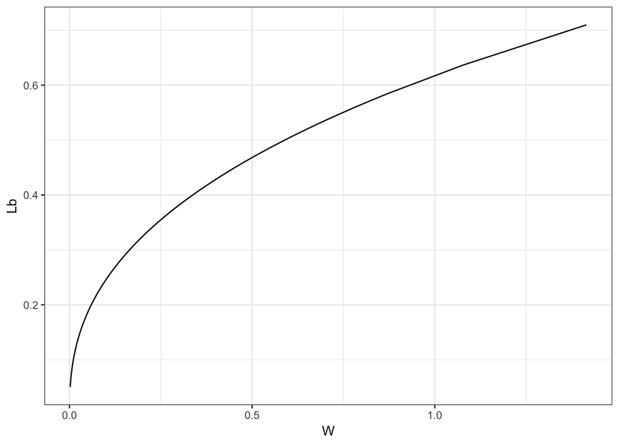

```r
p = list(rho=0.9,a = 3, gamma =1.5)
p$n = 1000
data = data.table(i=1:p$n, B = 0, W = exp(rnorm(p$n) -3))

# solve for lambda
data[, Lb := ((p$rho*W - B)/(p$a))^(1/(1+p$gamma))]
data[, Lb := pmin(Lb,pmax(Lb,0),1)]

data[, D := rexp(p$n, rate = Lb)]

ggplot(data,aes(x=W,y=Lb)) + geom_line() + theme_bw()
```

# Estimating

Question 3 The log-likelihood function is given by
$$\begin{align}
l_n(\theta)&=\log(Pr(\{D_i,W_i\}_{i=1}^N|\theta)) \\
&= \log(Pr(\{W_i\}_{i=1}^N|\theta)\cdot Pr(\{D_i\}_{i=1}^N|\{W_i\}_{i=1}^N,\theta)) \\
&=\log\left(\prod_{i=1}^{N}\frac{1}{W_i\sqrt{2\pi\sigma^2}}e^{-\frac{(\log W_i-\mu)^2}{2\sigma^2}}\cdot \lambda_i^*e^{-\lambda_i^*D_i}\right) \\
&=\log\left(\prod_{i=1}^{N}\frac{1}{W_i\sqrt{2\pi\sigma^2}}e^{-\frac{(\log W_i-\mu)^2}{2\sigma^2}}\cdot \left(\frac{\rho W_i-b_i}{a}\right)^{\frac{1}{1+\gamma}}e^{-\left(\frac{\rho W_i-b_i}{a}\right)^{\frac{1}{1+\gamma}}D_i}\right) \\
&=\sum_{i=1}^n\log\left(\frac{1}{W_i\sqrt{2\pi\sigma^2}}\right)-\frac{(\log W_i-\mu)^2}{2\sigma^2}+\frac{1}{1+\gamma}\log\left(\frac{\rho W_i-b_i}{a}\right)-\left(\frac{\rho W_i-b_i}{a}\right)^{\frac{1}{1+\gamma}}D_i. \\
\end{align}$$
We can drop the first two terms since they do not contain our parameters of interest $a$ and $\gamma$:
$$l_n(\theta) = \sum_{i=1}^n \frac{1}{1+\gamma}\log\left(\frac{\rho W_i-b_i}{a}\right)-\left(\frac{\rho W_i-b_i}{a}\right)^{\frac{1}{1+\gamma}}D_i.$$
The following function calculates the likelihood given observed wages and unemployment duration according to the equation above:

```r
lik.homo <- function(Wages,Duration,Benefits,p){
  likelihood <- sum(1/(1+p$gamma)*log((p$rho*Wages-Benefits)/p$a)-((p$rho*Wages-Benefits)/p$a)^(1/(1+p$gamma))*Duration)
}
```

We evaluate over a grid to search for the likelihood maximizing values of $a$ and $\gamma$.

```r
a_dim = 50
g_dim = 50
likelihood = array(0,dim=c(a_dim,g_dim))
a_test = seq(1, 5, length.out=a_dim)
g_test = seq(0.5, 2.5, length.out=g_dim)
i=1
j=1
p$a = a_test[1]
p$gamma = g_test[1]
maxlik = lik.homo(data$W,data$D,data$B,p)
for (a in a_test){
  p$a = a
for (gamma in g_test){
  p$gamma = gamma
  likelihood[i,j]=lik.homo(data$W,data$D,data$B,p)
  if (likelihood[i,j]>maxlik){
    maxlik=likelihood[i,j]
    astar = a
    gstar = gamma
  }
  j=j+1
}
  j=1
  i=i+1
}
print(paste0('ahat = ', astar))
```

```
## [1] "ahat = 3.85714285714286"
```

```r
print(paste0('gammahat = ', gstar))
```

```
## [1] "gammahat = 1.64285714285714"
```

We see that the MLE estimates of a and $\gamma$ are close to the true values ($a=3$, $\gamma=1.5$).

Question 4 The FOC condition for $a$ is given by
$$\sum_{i=1}^n-\frac{1}{(1+\gamma)(\rho W_i - b_i)a}+\frac{1}{(1+\gamma)a^2}\left(\frac{\rho W_i - b_i}{a}\right)^{-\frac{\gamma}{1+\gamma}}D_i=0 \\
\sum_{i=1}^n-\frac{1}{(1+\gamma)a}\left(\frac{1}{\rho W_i-b_i}\right)^{\frac{1}{1+\gamma}}+\frac{1}{(1+\gamma)a^{\frac{2+\gamma}{1+\gamma}}}D_i=0 \\
\sum_{i=1}^n\frac{1}{(1+\gamma)}a^{-\frac{1}{1+\gamma}}D_i=\sum_{i=1}^n\frac{1}{(1+\gamma)}\left(\frac{1}{\rho W_i-b_i}\right)^{\frac{1}{1+\gamma}} \\
a = \left\{\frac{1}{\sum_{i=1}^nD_i}\sum_{i=1}^n\left(\frac{1}{\rho W_i-b_i}\right)^{\frac{1}{1+\gamma}}\right\}^{-(1+\gamma)} \\
a = \left(\sum_{i=1}^nD_i\right)^{1+\gamma}\left\{\sum_{i=1}^n\left(\frac{1}{\rho W_i-b_i}\right)^{\frac{1}{1+\gamma}}\right\}^{-(1+\gamma)} \quad (= a^{MLE}).$$

# Random Effect

Now we assume that the population is divided into three latent groups indexed by $k$, each with their own parameter $a_k$. Simulating the data:

```r
p = list(rho=0.9,a = c(1,3,5), gamma =1.5, pk=c(0.2,0.5,0.3))

p$n = 10000
data = data.table(i=1:p$n, B = 0, W = exp(rnorm(p$n) -2))

# draw the latent type
data[, k := sample.int(3,.N,prob = p$pk,replace=T)]

# solve for lambda
data[, Lb := ((p$rho*W - B)/(p$a[k]))^(1/(1+p$gamma))]
data[, Lb := pmin(pmax(Lb,0),1)] # bound it between 0 and 1

data[, D := rexp(p$n, rate = Lb)]
```

Question 5 The likelihood function of our random effect model is given by

$$\begin{align}
L_n(\theta)&=Pr(\{D_i,W_i\}_{i=1}^N|\theta) \\
&=\prod_{i=1}^{N}\sum_{k=1}^3 Pr(D_i,W_i,k_i=k|\theta) \\
&= \prod_{i=1}^{N}\sum_{k=1}^3p_k\cdot Pr(W_i|\theta,k_i=k)\cdot Pr(D_i|W_i,\theta,k_i=k) \\
&=\prod_{i=1}^{N}\sum_{k=1}^3 p_k \frac{1}{W_i\sqrt{2\pi\sigma^2}}e^{-\frac{(\log W_i-\mu)^2}{2\sigma^2}}\cdot \lambda_i^*e^{-\lambda_i^*D_i} \\
&=\prod_{i=1}^{N}\sum_{k=1}^3 p_k \frac{1}{W_i\sqrt{2\pi\sigma^2}}e^{-\frac{(\log W_i-\mu)^2}{2\sigma^2}}\cdot \left(\frac{\rho W_i-b_i}{a_k}\right)^{\frac{1}{1+\gamma}}e^{-\left(\frac{\rho W_i-b_i}{a_k}\right)^{\frac{1}{1+\gamma}}D_i} \\
&=\prod_{i=1}^{N}\frac{1}{W_i\sqrt{2\pi\sigma^2}}e^{-\frac{(\log W_i-\mu)^2}{2\sigma^2}}\sum_{k=1}^3 p_k \left(\frac{\rho W_i-b_i}{a_k}\right)^{\frac{1}{1+\gamma}}e^{-\left(\frac{\rho W_i-b_i}{a_k}\right)^{\frac{1}{1+\gamma}}D_i}
\end{align}$$
Taking the log of the likelihood function,
$$\begin{align}
l_n(\theta)&=\sum_{i=1}^N\log\left(\frac{1}{W_i\sqrt{2\pi\sigma^2}}e^{-\frac{(\log W_i-\mu)^2}{2\sigma^2}}\sum_{k=1}^3 p_k \left(\frac{\rho W_i-b_i}{a_k}\right)^{\frac{1}{1+\gamma}}e^{-\left(\frac{\rho W_i-b_i}{a_k}\right)^{\frac{1}{1+\gamma}}D_i}\right) \\
&=\sum_{i=1}^N\log\left(\frac{1}{W_i\sqrt{2\pi\sigma^2}}e^{-\frac{(\log W_i-\mu)^2}{2\sigma^2}}\right) +\log\left(\sum_{k=1}^3 p_k \left(\frac{\rho W_i-b_i}{a_k}\right)^{\frac{1}{1+\gamma}}e^{-\left(\frac{\rho W_i-b_i}{a_k}\right)^{\frac{1}{1+\gamma}}D_i}\right)
\end{align}$$
Since the first term has no dependence on the underlying parameters $\theta$, we drop it:
$$\begin{align}
l_n(\theta)=\sum_{i=1}^N\log\left(\sum_{k=1}^3 p_k \left(\frac{\rho W_i-b_i}{a_k}\right)^{\frac{1}{1+\gamma}}e^{-\left(\frac{\rho W_i-b_i}{a_k}\right)^{\frac{1}{1+\gamma}}D_i}\right)
\end{align}$$

The following function calculates the likelihood given observed wages and unemployment duration according to the equation above:

```r
lik.random <- function(Wages,Duration,Benefits,p){
  data[, i_likelihood:= log(sum(p$pk*((p$rho*W-B)/p$a)^(1/(1+p$gamma))*exp(-((p$rho*W-B)/p$a)^(1/(1+p$gamma))*D))), by = i]
  sum(data$i_likelihood)
}
```

We want to estimate $\gamma, a_k$ and $p_k$. To do this, we vary each of the parameters separately:

```r
dim = 50
# parameter test values
testgrid = data.table(gamma=1:dim)
testgrid[,gamma := seq(0.5, 2.5, length.out=dim)]
testgrid[,a1 := seq(0.5, 7, length.out=dim)]
testgrid[,a2 := seq(0.5, 7, length.out=dim)]
testgrid[,a3 := seq(0.5, 7, length.out=dim)]
testgrid[,pk1 := seq(0, 0.5, length.out=dim)]
testgrid[,pk2 := seq(0, 0.8, length.out=dim)]

estimands = names(testgrid)

#reformatting parameter list so we can loop over estimands
p2 = data.table(rho=0.9, a1=1, a2=3, a3=5, gamma=1.5, pk1=0.2, pk2=0.5, pk3=0.3)

#for storing likelihoods and estimates
liktable = data.table(i=1:dim)
estimates = data.table(i=1:1)

for (j in estimands){
  # list of test parameters
  pt = p
  pt2 = p2
  pt2[,(j)]<- testgrid[1,j, with=FALSE]
  pt2[,pk3:=1-pk1-pk2]
  #update original test parameter list
  pt$gamma = pt2$gamma
  pt$a[1] = pt2$a1
  pt$a[2] = pt2$a2
  pt$a[3] = pt2$a3
  pt$pk[1] = pt2$pk1
  pt$pk[2] = pt2$pk2
  pt$pk[3] = pt2$pk3
  #initializing column with maximum likelihood estimate
  estimates[,(j):=testgrid[1,j, with=FALSE]]

  maxlik = lik.random(data$W,data$D,data$B,pt)
  for (i in 1:dim){
    pt2[,(j)]<- testgrid[i,j, with=FALSE]
    pt2[,pk3:=1-pk1-pk2]
    #update original test parameter list
    pt$gamma = pt2$gamma
    pt$a[1] = pt2$a1
    pt$a[2] = pt2$a2
    pt$a[3] = pt2$a3
    pt$pk[1] = pt2$pk1
    pt$pk[2] = pt2$pk2
    pt$pk[3] = pt2$pk3
    lik = lik.random(data$W,data$D,data$B,pt)
    liktable[i,(j):=lik]
    #if likelihood is higher, set new max and update estimate
    if (lik > maxlik){
      maxlik = lik
      estimates[,(j)]<-testgrid[i,j, with=FALSE]
    }
  }
}
truth = data.table(gamma=1.5, a1=1, a2=3, a3=5, pk1=0.2, pk2=0.5, pk3=0.3)

print(estimates)
```

```
##    i    gamma        a1       a2       a3       pk1       pk2
## 1: 1 1.520408 0.7653061 2.755102 4.612245 0.2346939 0.5714286
```

```r
print(truth)
```

```
##    gamma a1 a2 a3 pk1 pk2 pk3
## 1:   1.5  1  3  5 0.2 0.5 0.3
```

As we can see, the likelihood picks close to the true values.

Question 6 Now we implement the EM algorithm. Starting with the true value of $\gamma$, we compute the posterior probability for each individual to be of type $i$ as follows
$$\begin{align}
q_i^{(t)}(k)&=Pr[k_i=k|W_i,D_i,\theta^{(t)}] \\
&=\frac{Pr[k_i=k,W_i,D_i|\theta^{(t)}]}{\sum_{k'=1}^3Pr[k_i=k',W_i,D_i|\theta^{(t)}]} \\
&=\frac{p_{k}\cdot Pr[W_i,D_i|\theta^{(t)},k_i=k]}{\sum_{k'=1}^3p_{k'}\cdot Pr[W_i,D_i|\theta^{(t)},k_i=k']} \\
&=\frac{p_{k}\cdot \frac{1}{W_i\sqrt{2\pi\sigma^2}}e^{-\frac{(\log W_i-\mu)^2}{2\sigma^2}} \left(\frac{\rho W_i-b_i}{a_k}\right)^{\frac{1}{1+\gamma}}e^{-\left(\frac{\rho W_i-b_i}{a_k}\right)^{\frac{1}{1+\gamma}}D_i}}{\sum_{k'=1}^3\left(p_{k'}\cdot \frac{1}{W_i\sqrt{2\pi\sigma^2}}e^{-\frac{(\log W_i-\mu)^2}{2\sigma^2}} \left(\frac{\rho W_i-b_i}{a_{k'}}\right)^{\frac{1}{1+\gamma}}e^{-\left(\frac{\rho W_i-b_i}{a_{k'}}\right)^{\frac{1}{1+\gamma}}D_i}\right)} \\
&=\frac{p_{k}\cdot \left(\frac{\rho W_i-b_i}{a_k}\right)^{\frac{1}{1+\gamma}}e^{-\left(\frac{\rho W_i-b_i}{a_k}\right)^{\frac{1}{1+\gamma}}D_i}}{\sum_{k'=1}^3\left(p_{k'}\cdot \left(\frac{\rho W_i-b_i}{a_{k'}}\right)^{\frac{1}{1+\gamma}}e^{-\left(\frac{\rho W_i-b_i}{a_{k'}}\right)^{\frac{1}{1+\gamma}}D_i}\right)} \\
&=\frac{p_{k}\cdot \left(\frac{1}{a_k}\right)^{\frac{1}{1+\gamma}}e^{-\left(\frac{\rho W_i-b_i}{a_k}\right)^{\frac{1}{1+\gamma}}D_i}}{\sum_{k'=1}^3\left(p_{k'}\cdot \left(\frac{1}{a_{k'}}\right)^{\frac{1}{1+\gamma}}e^{-\left(\frac{\rho W_i-b_i}{a_{k'}}\right)^{\frac{1}{1+\gamma}}D_i}\right)}.
\end{align}$$

Given the $q_i^{(t)}(k)$, we then find the values of $\theta^{(t)}$ maximizing the expected likelihood. That is, we solve:
$$\begin{align}
\theta^{(t+1)} &= \arg\max_{\theta} \sum_i\sum_k q_i^{(t)}(k)Pr[W_i,D_i,k_i=k|\theta^{(t)}] \\
&= \arg\max_{\theta} \sum_i\sum_k q_i^{(t)}(k)\cdot \log\left(p_k \frac{1}{W_i\sqrt{2\pi\sigma^2}}e^{-\frac{(\log W_i-\mu)^2}{2\sigma^2}}\cdot \left(\frac{\rho W_i-b_i}{a_k}\right)^{\frac{1}{1+\gamma}}e^{-\left(\frac{\rho W_i-b_i}{a_k}\right)^{\frac{1}{1+\gamma}}D_i}\right) \\
&= \arg\max_{\theta} \sum_i\sum_k q_i^{(t)}(k) \cdot \left( \log p_k +\frac{1}{1+\gamma}\log \left(\frac{\rho W_i-b_i}{a_k}\right)-\left(\frac{\rho W_i-b_i}{a_k}\right)^{\frac{1}{1+\gamma}}D_i \right)
\end{align}$$
We want to find the maximizing values of $p_k$ and $a_k$. Imposing the additional constraint that the $\sum_k p_k = 1$, we write the Lagrangian as:
$$\mathscr{L}= \sum_i\sum_k \left\{ q_i^{(t)}(k) \cdot \left( \log p_k +\frac{1}{1+\gamma}\log \left(\frac{\rho W_i-b_i}{a_k}\right)-\left(\frac{\rho W_i-b_i}{a_k}\right)^{\frac{1}{1+\gamma}}D_i \right) \right\} - \mu\left(\sum_k p_k-1\right)$$
The FOC’s are given by:

$$[p_k]: \frac{\sum_i q_i^{(t)}(k)}{p_k} = \mu \\
\sum_i q_i^{(t)}(k) =p_k\mu \\
\Rightarrow \sum_k\sum_i q_i^{(t)}(k) =\sum_k p_k\mu \\
\sum_k\sum_i q_i^{(t)}(k) = \mu \\
\Rightarrow p_k= \frac{\sum_i q_i^{(t)}(k)}{\sum_{k'}\sum_i q_i^{(t)}(k')}\\
[a_k]: \sum_iq_i^{(t)}(k) \left( -\frac{1}{(1+\gamma)(\rho W_i-b_i)a_k} + \frac{1}{(1+\gamma)a_k^2}\left(\frac{\rho W_i -b_i}{a_k}\right)^{-\frac{\gamma}{1+\gamma}}D_i\right)=0 \\
\sum_iq_i^{(t)}(k) \left( -\frac{1}{(1+\gamma)(\rho W_i-b_i)} + \frac{\left(\rho W_i -b_i\right)^{-\frac{\gamma}{1+\gamma}}D_i}{(1+\gamma)a_k^{\frac{1}{1+\gamma}}}\right)=0 \\
a_k^{-\frac{1}{1+\gamma}}\sum_iq_i^{(t)}(k) \left(\rho W_i -b_i\right)^{-\frac{\gamma}{1+\gamma}}D_i =\sum_i \frac{q_i^{(t)}(k)}{\rho W_i-b_i} \\
a_k^ =\left(\sum_i \frac{q_i^{(t)}(k)}{\rho W_i-b_i}\right)^{-(1+\gamma)} \cdot \left(\sum_iq_i^{(t)}(k) \left(\rho W_i -b_i\right)^{-\frac{\gamma}{1+\gamma}}D_i\right)^{1+\gamma}$$

The following function will perform the EM algorithm:

```r
em.random <- function(data,p){
  # E - step
  for (k in 1:3){
    qk = paste0("q",k)
    pk = p$pk[k]
    ak = p$a[k]
    data[,(qk):=(pk*(1/ak)^(1/(1+p$gamma))*exp(-((p$rho*W-B)/ak)^(1/(1+p$gamma))*D))/sum(p$pk*(1/p$a)^(1/(1+p$gamma))*exp(-((p$rho*W-B)/p$a)^(1/(1+p$gamma))*D)), by=i]
  }

  # M - step
  for (k in 1:3){
  p$pk[k] = sum(data[,q(k)])/sum(data$q1+data$q2+data$q3)
  p$ak[k] = sum(data[,q(k)]/(p$rho*data$W-data$B))^(-(1+p$gamma))*sum(data[,q(k)]*(p$rho*W-B)^(p$gamma/(1+p$gamma))*D)^(1+p$gamma)
  }
}
```